```python
import pandas as pd
import numpy as np
import os

import util

import matplotlib.pyplot as plt
plt.style.use('seaborn-white')
plt.rc('figure', dpi=100, figsize=(10, 5))
plt.rc('font', size=12)
```

# Lecture 14 – HTTP Basics

## DSC 80, Spring 2022

### Announcements

- Midterm Exam grades are released! See [#935](https://campuswire.com/c/G325FA25B/feed/935) for details.
  - Regrades are due next Thursday.
- Project 2 is due **tomorrow at 11:59PM**.
- Lab 5 is due on **Monday, May 2nd at 11:59PM**.

### Agenda

- Recap: Imputation.
- Introduction to HTTP.
- Making HTTP requests.
  - See the [course notes](https://notes.dsc80.com/content/07/requests.html) for more details.

## Recap: Imputation

### Example: Heights 🧍📏

```python
heights = pd.read_csv(os.path.join('data', 'heights.csv'))
heights = (
    heights
    .rename(columns={'childHeight': 'child', 'childNum': 'number'})
    .drop('midparentHeight', axis=1)
)
heights.head()
```

|  | family | father | mother | children | number | gender | child |
| --- | --- | --- | --- | --- | --- | --- | --- |
| 0 | 1 | 78.5 | 67.0 | 4 | 1 | male | 73.2 |
| 1 | 1 | 78.5 | 67.0 | 4 | 2 | female | 69.2 |
| 2 | 1 | 78.5 | 67.0 | 4 | 3 | female | 69.0 |
| 3 | 1 | 78.5 | 67.0 | 4 | 4 | female | 69.0 |
| 4 | 2 | 75.5 | 66.5 | 4 | 1 | male | 73.5 |

```python
np.random.seed(42) # So that we get the same results each time (for lecture)
heights_mcar = util.make_mcar(heights, 'child', pct=0.50)
heights_mcar.head()
```

|  | family | father | mother | children | number | gender | child |
| --- | --- | --- | --- | --- | --- | --- | --- |
| 0 | 1 | 78.5 | 67.0 | 4 | 1 | male | 73.2 |
| 1 | 1 | 78.5 | 67.0 | 4 | 2 | female | 69.2 |
| 2 | 1 | 78.5 | 67.0 | 4 | 3 | female | NaN |
| 3 | 1 | 78.5 | 67.0 | 4 | 4 | female | NaN |
| 4 | 2 | 75.5 | 66.5 | 4 | 1 | male | 73.5 |

### Mean imputation

The `'child'` column has missing values.

- If `'child'` is MCAR, then fill in each of the missing values using the **mean of the observed values**.
- If `'child'` is MAR dependent on a categorical column, then fill in each of the missing values using the **mean of the observed values in each category**. For instance, if `'child'` is MAR dependent on `'gender'`, we can fill in:
  - missing female `'child'` heights with the observed mean for female children, and
  - missing male `'child'` heights with the observed mean for male children.
- If `'child'` is MAR dependent on a numerical column, then **bin the numerical column to make it categorical**, then follow the procedure above. See Lab 5, Question 3!
- Mean imputation, when done correctly, creates a distribution whose mean is an unbiased estimate of the true distribution's mean, but whose variance is **an underestimate** of the true variance.

```python
heights_mcar_mfilled = heights_mcar.fillna(heights_mcar['child'].mean())
heights_mcar_mfilled['child'].head()
```

```
0    73.200000
1    69.200000
2    66.640685
3    66.640685
4    73.500000
Name: child, dtype: float64
```

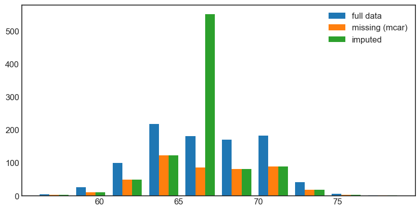

```python
plt.hist([heights['child'], heights_mcar['child'].dropna(), heights_mcar_mfilled['child']])
plt.legend(['full data', 'missing (mcar)', 'imputed']);
```

### Probabilistic imputation

The `'child'` column has missing values.

- If `'child'` is MCAR, then fill in each of the missing values with **randomly selected observed `'child'` heights**.
  - For instance, if there are 5 missing `'child'` values, pick 5 of the not-missing `'child'` values.
- If `'child'` is MAR dependent on a categorical column, sample from the observed values separately for each category.

```python
# Figure out the number of missing values
num_null = heights_mcar['child'].isna().sum()

# Sample that number of values from the observed dataset
fill_values = heights_mcar['child'].dropna().sample(num_null, replace=True)

# Find the positions where values in heights_mcar are missing
fill_values.index = heights_mcar.loc[heights_mcar['child'].isna()].index

# Fill in the missing values
heights_mcar_dfilled = heights_mcar.fillna({'child': fill_values.to_dict()})  # fill the vals
```

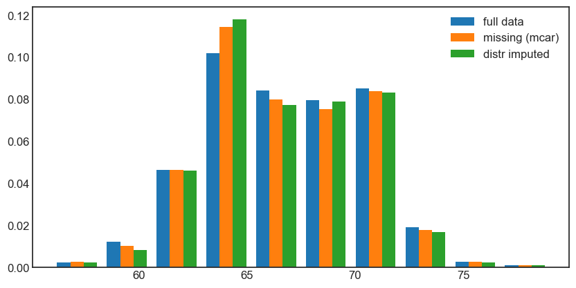

```python
plt.hist([heights['child'], heights_mcar['child'], heights_mcar_dfilled['child']], density=True);
plt.legend(['full data','missing (mcar)', 'distr imputed']);
```

No spikes!

### Observations

- With probabilistic imputation, the missing values were filled in with observed values in the dataset.
- If a value was never observed in the dataset, it will never be used to fill in a missing value.
  - For instance, if the observed heights were 68, 69, and 69.5 inches, we will never fill a missing value with 68.5 inches even though it's a perfectly reasonable height.
- Solution? Create a histogram (with `np.histogram`) to bin the data, then sample from the histogram. See Lab 5, Question 4.

### Randomness

- Unlike mean imputation, probabilistic imputation is **random** – each time you run the cell in which imputation is performed, the results could be different.
- **Multiple imputation**: Generate multiple imputed datasets and aggregate the results!
  - Similar to bootstrapping.

### Multiple imputation

Steps:

1. Start with observed and incomplete data.
2. Create several **imputed** versions of the data through a probabilistic procedure.
   - The imputed datasets are identical for the observed data entries.
   - They differ in the imputed values.
   - The differences reflect our **uncertainty** about what value to impute.
3. Then, estimate the parameters of interest for **each** imputed dataset.
   - For instance, the mean, standard deviation, median, etc.
4. Finally, pool the parameter estimates into one estimate.

Let's try this procedure out on the `heights_mcar` dataset.

```python
heights_mcar.head()
```

|  | family | father | mother | children | number | gender | child |
| --- | --- | --- | --- | --- | --- | --- | --- |
| 0 | 1 | 78.5 | 67.0 | 4 | 1 | male | 73.2 |
| 1 | 1 | 78.5 | 67.0 | 4 | 2 | female | 69.2 |
| 2 | 1 | 78.5 | 67.0 | 4 | 3 | female | NaN |
| 3 | 1 | 78.5 | 67.0 | 4 | 4 | female | NaN |
| 4 | 2 | 75.5 | 66.5 | 4 | 1 | male | 73.5 |

```python
# This function implements the 3-step process we studied earlier
def create_imputed(col):
    num_null = col.isna().sum()
    fill_values = col.dropna().sample(num_null, replace=True)
    fill_values.index = col.loc[col.isna()].index
    return col.fillna(fill_values.to_dict())
```

Each time we run the following cell, it generates a new imputed version of the `'child'` column.

```python
create_imputed(heights_mcar['child']).head()
```

```
0    73.2
1    69.2
2    67.7
3    66.0
4    73.5
Name: child, dtype: float64
```

Let's run the above procedure 100 times.

```python
mult_imp = pd.concat([create_imputed(heights_mcar['child']).rename(k) for k in range(100)], axis=1)
mult_imp.head()
```

|  | 0 | 1 | 2 | 3 | 4 | 5 | 6 | 7 | 8 | 9 | ... | 90 | 91 | 92 | 93 | 94 | 95 | 96 | 97 | 98 | 99 |
| --- | --- | --- | --- | --- | --- | --- | --- | --- | --- | --- | --- | --- | --- | --- | --- | --- | --- | --- | --- | --- | --- |
| 0 | 73.2 | 73.2 | 73.2 | 73.2 | 73.2 | 73.2 | 73.2 | 73.2 | 73.2 | 73.2 | ... | 73.2 | 73.2 | 73.2 | 73.2 | 73.2 | 73.2 | 73.2 | 73.2 | 73.2 | 73.2 |
| 1 | 69.2 | 69.2 | 69.2 | 69.2 | 69.2 | 69.2 | 69.2 | 69.2 | 69.2 | 69.2 | ... | 69.2 | 69.2 | 69.2 | 69.2 | 69.2 | 69.2 | 69.2 | 69.2 | 69.2 | 69.2 |
| 2 | 64.5 | 72.0 | 67.0 | 69.0 | 69.0 | 70.0 | 69.0 | 67.0 | 67.0 | 64.0 | ... | 65.7 | 65.0 | 65.7 | 70.7 | 73.0 | 65.0 | 66.0 | 63.0 | 71.0 | 69.0 |
| 3 | 63.5 | 64.5 | 61.7 | 67.2 | 61.0 | 64.0 | 66.0 | 56.0 | 60.0 | 62.0 | ... | 67.2 | 64.5 | 68.0 | 62.0 | 64.0 | 62.0 | 66.0 | 65.5 | 69.0 | 64.5 |
| 4 | 73.5 | 73.5 | 73.5 | 73.5 | 73.5 | 73.5 | 73.5 | 73.5 | 73.5 | 73.5 | ... | 73.5 | 73.5 | 73.5 | 73.5 | 73.5 | 73.5 | 73.5 | 73.5 | 73.5 | 73.5 |

5 rows × 100 columns

Let's plot some of the imputed columns above.

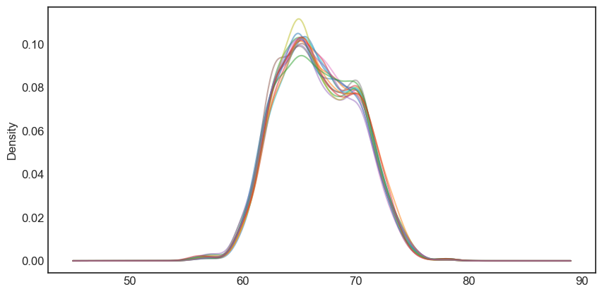

```python
# Random sample of 15 imputed columns
mult_imp.sample(15, axis=1).plot(kind='kde', alpha=0.5, legend=False);
```

Let's look at the distribution of means across the imputed columns.

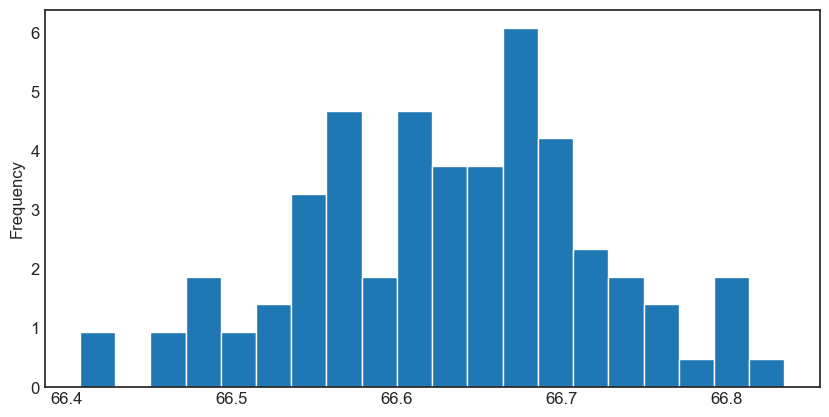

```python
mult_imp.mean().plot(kind='hist', bins=20, ec='w', density=True);
```

### Summary of imputation techniques

See the end of Lecture 13 for a detailed summary of all imputation techniques that we've seen so far.

## Introduction to HTTP

[figure not shown]

### Collecting data

- Often, the data you need doesn't exist in "clean" `.csv` files.
- **Solution:** collect your own data!
  - Design and administer your own survey or run an experiment.
  - Find related data on the internet.

### Data on the internet

- The internet contains **massive** amounts of historical record.
  - News stories provide a record of world events.
  - Social networks and commerce sites provide an insight into human behavior.
- For most questions you can think of, the data to answer the question exists somewhere on the internet.

### Collecting data from the internet

- There are two ways to programmatically access data on the internet.
  - Through an API.
  - By scraping.
- We will discuss the differences between both approaches next lecture, but for now, the important part is that they **both use HTTP**.

### HTTP

- HTTP stands for **Hypertext Transfer Protocol**.
  - It was developed in 1989 by Tim Berners-Lee (and friends).
- It is a **request-response** protocol.
  - Protocol = set of rules.
- HTTP allows...
  - computers to talk to each other over a network.
  - devices to fetch data from "web servers".
- The "S" in HTTPS stands for "secure".

[figure not shown]

UCSD was a node in ARPANET, the predecessor to the modern internet ([source](https://en.wikipedia.org/wiki/ARPANET#/media/File:Arpanet_map_1973.jpg/)).

### The request-response model

HTTP follows the **request-response** model.

[figure not shown]

- A **request** is made by the **client**.
- A **response** is returned by the **server**.
- **Example:** YouTube 🎥.
  - Your phone's web browser, a **client**, makes an HTTP **request** to view a video.
  - The **server**, YouTube, is a computer that is sitting somewhere else.
  - The server returns a **response** that contains the video.

### Request methods

- The request methods you will use most often are `GET` and `POST`.
  - `GET` is used to request data **from** a specified resource.
  - `POST` is used to **send** data to the server.
    - e.g. uploading a photo to Instagram or entering credit card information on Amazon.
- See [Mozilla's web docs](https://developer.mozilla.org/en-US/docs/Web/HTTP/Methods) for a detailed list of request methods.

### Example `GET` request

Below is an example `GET` HTTP request made by a browser when accessing datascience.ucsd.edu.

```
GET / HTTP/1.1
Host: datascience.ucsd.edu
User-Agent: Mozilla/5.0 (Macintosh; Intel Mac OS X 10_15_7) AppleWebKit/537.36 (KHTML, like Gecko) Chrome/100.0.4896.127 Safari/537.36
Connection: keep-alive
Accept-Language: en-US,en;q=0.9
```

- The first line (`GET / HTTP/1.1`) is called the "request line", and the lines afterwards are called "header fields". We could also provide a "body" after the header fields.
- To see HTTP requests in Google Chrome, follow [these steps](https://mkyong.com/computer-tips/how-to-view-http-headers-in-google-chrome/).

### Example `GET` response

The response below was generated by executing the request on the previous slide.

```
HTTP/1.1 200 OK
Date: Fri, 29 Apr 2022 02:54:41 GMT
Server: Apache
Link: <https://datascience.ucsd.edu/wp-json/>; rel="https://api.w.org/"
Link: <https://datascience.ucsd.edu/wp-json/wp/v2/pages/2427>; rel="alternate"; type="application/json"
Link: <https://datascience.ucsd.edu/>; rel=shortlink
Content-Type: text/html; charset=UTF-8

<!DOCTYPE html>
<html lang="en-US">
<head>
    <meta charset="UTF-8">
    <link rel="profile" href="https://gmpg.org/xfn/11">
    <style media="all">img.wp-smiley,img.emoji{display:inline !important;border:none
...
```

### Consequences of the request-response model

- When a request is sent to view content on a webpage, the server must:
  - process your request (i.e. prepare data for the response).
  - send content back to the client in its response.
- Remember, servers are computers.
  - Someone has to pay to keep these computers running.
  - **This means that every time you access a website, someone has to pay.**

### Example: [istheshipstuck.com](https://istheshipstillstuck.com)

[figure not shown]

Read [*Inside a viral website*](https://notfunatparties.substack.com/p/inside-a-viral-website), an account of what it's like to run a site that gained 50 million+ views in 5 days.

## Making HTTP requests

### Making HTTP requests

There are (at least) two ways to make HTTP requests:

- From the command line, with `curl`.
- From Python, with the `requests` package.

### Making HTTP requests using `curl`

[`curl`](https://curl.haxx.se/docs/httpscripting.html) is a **command-line tool** that sends HTTP requests, like a browser.

1. The client, `curl`, sends a HTTP request.
2. The request contains a method (e.g. `GET` or `POST`).
3. The HTTP server responds with
   - a status line, indicating if things went well,
   - response headers, and
   - (usually) a response body, containing the requested data.

### Example: `GET` requests via `curl`

- By default, `curl` issues a `GET` request.
- Remember, you can run command-line commands in a Jupyter Notebook by placing a `!` before them.

```
curl -v https://httpbin.org/html
# (`-v` is short for verbose)
```

- After running the command, go to https://httpbin.org/html in your browser. What do you notice?

```python
!curl -v https://httpbin.org/html
```

### Queries in a `GET` request

- In order to request more specific information, we can include a **query string** in the URL.
- `?` begins a query. For instance,

```
https://www.google.com/search?q=ucsd+dsc+80+hard&client=safari
```

- This method works well when sending small amounts of data.
- We will use a similiar technique when working with APIs next lecture.

### Example: `POST` requests via `curl`

- When using `curl`, `-d` is short for `POST`.
- Below is an example `curl` `POST` request that sends `'King Triton'` as the parameter `'name'`.

```
curl -d 'name=King Triton' https://httpbin.org/post
```

```python
!curl -d 'name=King Triton' https://httpbin.org/post
```

- Run the cell below. Notice the difference?

```python
!curl -d 'name=King Triton' https://youtube.com
```

### Making HTTP requests using `requests`

- `requests` is a Python package that allows you to use Python to interact with the internet!
- There are other packages that work similarly (e.g. `urllib`), but `requests` is arguably the easiest to use.

```python
import requests
```

### Example: `GET` requests via `requests`

To access the source code of the UCSD home page, all we need to run is the following:

```
text = requests.get('https://ucsd.edu').text
```

```python
url = 'https://ucsd.edu'
resp = requests.get(url)
```

`resp` is now a `Response` object.

```python
resp
```

```
<Response [200]>
```

The `text` attribute of `resp` is a string that containing the entire response.

```python
type(resp.text)
```

```
str
```

```python
len(resp.text)
```

```
43692
```

```python
print(resp.text[:1000])
```

```
<!DOCTYPE html>
<html lang="en">
  <head>









    <meta charset="utf-8"/>
    <meta content="IE=edge" http-equiv="X-UA-Compatible"/>
    <meta content="width=device-width, initial-scale=1" name="viewport"/>
    <title>University of California San Diego</title>
    <meta content="University of California, San Diego" name="ORGANIZATION"/>
    <meta content="index,follow,noarchive" name="robots"/>
    <meta content="UCSD" name="SITE"/>
    <meta content="University of California San Diego" name="PAGETITLE"/>
    <meta content="The University California San Diego is one of the world's leading public research universities, located in beautiful La Jolla, California" name="DESCRIPTION"/>
    <link href="favicon.ico" rel="icon"/>








<!-- Site-specific CSS files -->

  <link href="https://www.ucsd.edu/_resources/css/vendor/brix_sans.css" rel="stylesheet" type="text/css"/>

  <!-- CSS complied from style overrides -->
  <link href="https://www.ucsd.edu/_resources/css/s
```

The `url` attribute contains the URL that we accessed.

```python
resp.request.url
```

```
'https://ucsd.edu/'
```

### Example: `POST` requests via `requests`

```python
post_response = requests.post('https://httpbin.org/post',
                              data={'name': 'King Triton'})
post_response
```

```
<Response [200]>
```

```python
print(post_response.text)
```

```
{
  "args": {},
  "data": "",
  "files": {},
  "form": {
    "name": "King Triton"
  },
  "headers": {
    "Accept": "*/*",
    "Accept-Encoding": "gzip, deflate, br",
    "Content-Length": "16",
    "Content-Type": "application/x-www-form-urlencoded",
    "Host": "httpbin.org",
    "User-Agent": "python-requests/2.26.0",
    "X-Amzn-Trace-Id": "Root=1-626b9412-7d96f8fc5ad980b61f34ae79"
  },
  "json": null,
  "origin": "70.95.172.151",
  "url": "https://httpbin.org/post"
}
```

### HTTP status codes

- When we **request** data from a website, the server includes an **HTTP status code** in the response.
- The most common status code is `200`, which means there were no issues.
- Other times, you will see a different status code, describing some sort of event or error.
  - e.g. `404`: page not found; `500`: internal server error.
  - [The first digit of a status describes its general "category".](https://developer.mozilla.org/en-US/docs/Web/HTTP/Status)
- See https://httpstat.us for a list of all HTTP status codes.
  - It also has example sites for each status code.
  - For example, https://httpstat.us/404 returns a `404`.

```python
r = requests.get('https://httpstat.us/503')
print(r.status_code)
```

```
503
```

```python
r.text
```

```
'503 Service Unavailable'
```

### Successful requests ✅

- You can check if a request was successful using the `ok` attribute, which returns a bool.
  - If a status is in the 200s, then it is successful.
- Unsuccessful requests can be re-tried, depending on the issue.
  - Wait a little, then try the request again.
  - You can even re-try requests programmatically (e.g. using a loop). If rate of requests is too high, slow down requests between each retry (e.g. using `time.sleep`).
- See the [course notes](https://notes.dsc80.com/content/07/requests.html#responsible-use-of-http-requests) for more examples.

```python
status_codes = [200, 201, 403, 404, 503]

for code in status_codes:
    r = requests.get(f'https://httpstat.us/{code}')
    print(f'{code} ok: {r.ok}')
```

```
200 ok: True
201 ok: True
403 ok: False
404 ok: False
503 ok: False
```

- The `raise_for_status` request method raises an exception when the status code is not-ok.

```python
requests.get('https://httpstat.us/400').raise_for_status()
```

```
---------------------------------------------------------------------------
HTTPError                                 Traceback (most recent call last)
/var/folders/pd/w73mdrsj2836_7gp0brr2q7r0000gn/T/ipykernel_8477/2094305732.py in <module>
----> 1 requests.get('https://httpstat.us/400').raise_for_status()

~/opt/anaconda3/lib/python3.9/site-packages/requests/models.py in raise_for_status(self)
    951
    952         if http_error_msg:
--> 953             raise HTTPError(http_error_msg, response=self)
    954
    955     def close(self):

HTTPError: 400 Client Error: Bad Request for url: https://httpstat.us/400
```

### The data formats of the internet

The internet currently relies on two key data formats – HTML and JSON.

- The response body of a `GET` request is usually either JSON (when using an API) or HTML (when accessing a webpage).
- The response body of a `POST` request is usually JSON.

[figure not shown]

### JSON

- JSON stands for **JavaScript Object Notation**.
- It is a lightweight format for storing and transferring data.
- It is:
  - very easy for computers to read and write.
  - moderately easy for programmers to read and write by hand.
  - meant to be generated and parsed.
- Most modern languages have an interface for working with JSON objects.
  - JSON objects *resemble* Python dictionaries (but are not the same!).
- JSON is slowly replacing XML, another text-based format for sending data from/to servers.

### JSON data types

- string: anything inside double quotes.
- number: any number (no difference between ints and floats).
- boolean: `true` and `false`.
- array: anything wrapped in `[]`.
- null: JSON's empty value, denoted by `null`.
- object: a collection of key-value pairs (like dictionaries).
  - Keys must be strings, values can be anything (even other objects).

See [json-schema.org](https://json-schema.org/understanding-json-schema/reference/type.html) for more details.

### Example JSON object

See `data/family.json`.

[figure not shown]

```python
import json
```

```python
f = open(os.path.join('data', 'family.json'), 'r')
family_tree = json.load(f)
```

```python
family_tree
```

```
{'name': 'Grandma',
 'age': 94,
 'children': [{'name': 'Dad',
   'age': 60,
   'children': [{'name': 'Me', 'age': 23}, {'name': 'Brother', 'age': 21}]},
  {'name': 'My Aunt',
   'children': [{'name': 'Cousin 1', 'age': 34},
    {'name': 'Cousin 2',
     'age': 36,
     'children': [{'name': 'Cousin 2 Jr.', 'age': 2}]}]}]}
```

```python
family_tree['children'][0]['children'][0]['age']
```

```
23
```

### Aside: `eval`

- `eval`, which stands for "evaluate", is a function built into Python.
- It takes in a **string containing a Python expression** and evaluates it in the current context.

```python
x = 4
```

```python
eval('x + 5')
```

```
9
```

- It seems like `eval` can do the same thing that `json.load` does...

```python
f = open(os.path.join('data', 'family.json'), 'r')
eval(f.read())
```

```
{'name': 'Grandma',
 'age': 94,
 'children': [{'name': 'Dad',
   'age': 60,
   'children': [{'name': 'Me', 'age': 23}, {'name': 'Brother', 'age': 21}]},
  {'name': 'My Aunt',
   'children': [{'name': 'Cousin 1', 'age': 34},
    {'name': 'Cousin 2',
     'age': 36,
     'children': [{'name': 'Cousin 2 Jr.', 'age': 2}]}]}]}
```

- But you should **never use `eval`**. The next slide demonstrates why.

### `eval` gone wrong

- Observe what happens when we use `eval` on a string representation of a JSON object:

```python
f_other = open(os.path.join('data', 'evil_family.json'))
eval(f_other.read())
```

```
---------------------------------------------------------------------------
ValueError                                Traceback (most recent call last)
/var/folders/pd/w73mdrsj2836_7gp0brr2q7r0000gn/T/ipykernel_8477/3392341705.py in <module>
      1 f_other = open(os.path.join('data', 'evil_family.json'))
----> 2 eval(f_other.read())

<string> in <module>

~/Desktop/80/private/lectures/sp22/lec14/util.py in err()
    132 # For JSON evaluation example
    133 def err():
--> 134     raise ValueError('i just deleted all your files lol 😂')

ValueError: i just deleted all your files lol 😂
```

- Oh no! Since `evil_family.json`, which could have been downloaded from the internet, contained malicious code, we now lost all of our files.
- This happened because `eval` **evaluates** all parts of the input string as if it were Python code. **You never need to do this – instead, use the `json` library.**
  - `json.load` loads a JSON file from a file.
  - `json.loads` loads a JSON file from a string.

```python
f_other = open(os.path.join('data', 'evil_family.json'))
s = f_other.read()
s
```

```
'{\n    "name": "Grandma",\n    "age": 94,\n    "children": [\n        {\n        "name": util.err(),\n        "age": 60,\n        "children": [{"name": "Me", "age": 23}, \n                     {"name": "Brother", "age": 21}]\n        },\n        {\n        "name": "My Aunt",\n        "children": [{…
```

```python
json.loads(s)
```

```
---------------------------------------------------------------------------
JSONDecodeError                           Traceback (most recent call last)
/var/folders/pd/w73mdrsj2836_7gp0brr2q7r0000gn/T/ipykernel_8477/1938830664.py in <module>
----> 1 json.loads(s)

~/opt/anaconda3/lib/python3.9/json/__init__.py in loads(s, cls, object_hook, parse_float, parse_int, parse_constant, object_pairs_hook, **kw)
    344             parse_int is None and parse_float is None and
    345             parse_constant is None and object_pairs_hook is None and not kw):
--> 346         return _default_decoder.decode(s)
    347     if cls is None:
    348         cls = JSONDecoder

~/opt/anaconda3/lib/python3.9/json/decoder.py in decode(self, s, _w)
    335
    336         """
--> 337         obj, end = self.raw_decode(s, idx=_w(s, 0).end())
    338         end = _w(s, end).end()
    339         if end != len(s):

~/opt/anaconda3/lib/python3.9/json/decoder.py in raw_decode(self, s, idx)
    353             obj, end = self.scan_once(s, idx)
    354         except StopIteration as err:
--> 355             raise JSONDecodeError("Expecting value", s, err.value) from None
    356         return obj, end

JSONDecodeError: Expecting value: line 6 column 17 (char 84)
```

- Since `util.err()` is not a string in JSON (there are no quotes around it), `json.loads` is not able to parse it as a JSON object.
- This "safety check" is intentional.

### Handling *unfamiliar* data

- Never trust data from an unfamiliar site.
- **Never** use `eval` on "raw" data that you didn't create!
- The JSON data format needs to be **parsed**, not evaluated as a dictionary.
  - It was designed with safety in mind!

### Summary

- HTTP is the protocol the internet uses for transferring information.
- Clients can make `GET` HTTP requests to ask for information and `POST` HTTP requests to send information.
- Servers send responses with the desired information.
- We can use `curl` in the command-line or the `requests` Python package to make HTTP requests.
- The two main file formats used for storing information on the internet are HTML and JSON.
- JSON objects resemble Python dictionaries, but they are not quite the same. Use the `json` package to parse them, **not** `eval`.
- **Next time:** Using HTTP to make API requests and scrape the web. Parsing HTML files.